# Week 2: Data Splitting and Preprocessing with recipes

- Show All Code
- Hide All Code
- View Source

IBM 6540 — Applied Machine Learning for Marketing

Author

Jae Jung

Published

June 17, 2026

# Learning Objectives

By the end of this notebook you will be able to:

1. Split data into training and test sets in a principled way using `rsample`
2. Explain *why* preprocessing must be learned on training data only
3. Build a `recipe()` pipeline for common transformations: log scaling, dummy encoding, imputation, and normalization
4. Inspect and debug a recipe with `prep()` / `bake()`
5. Connect a recipe to a model inside a `workflow()`

> **Textbook reference:** *Tidy Modeling with R* (TMWR), Chapters 5 & 8 (https://www.tmwr.org/splitting, https://www.tmwr.org/recipes)

# 1 Setup

```r
library(tidymodels) # umbrella: rsample, recipes, parsnip, workflows, yardstick
library(tidyverse)
library(janitor) # clean_names()
library(skimr) # skim()

tidymodels_prefer() # resolve function-name conflicts
set.seed(2024)
```

# 2 The Marketing Dataset

We use a synthetic **direct-mail** dataset that mirrors a real acquisition campaign. Each row is one prospect; the outcome is whether they **responded** (bought).

```r
# ── Synthetic direct-mail dataset ──────────────────────────────────────────────
n <- 3000

mail_data <- tibble(
  customer_id = paste0("C", str_pad(1:n, 5, pad = "0")),
  age = round(rnorm(n, mean = 45, sd = 12)),
  income = round(rlnorm(n, meanlog = 10.8, sdlog = 0.6)), # right-skewed
  recency_days = round(rexp(n, rate = 1 / 60)), # days since last purchase
  freq_12mo = rpois(n, lambda = 3), # purchases in 12 months
  avg_order_amt = round(rlnorm(n, meanlog = 4.2, sdlog = 0.5), 2),
  channel = sample(
    c("email", "direct_mail", "digital"),
    n,
    replace = TRUE,
    prob = c(0.5, 0.3, 0.2)
  ),
  region = sample(
    c("West", "South", "Midwest", "Northeast"),
    n,
    replace = TRUE
  ),
  loyalty_tier = sample(
    c("Bronze", "Silver", "Gold", "Platinum"),
    n,
    replace = TRUE,
    prob = c(0.4, 0.3, 0.2, 0.1)
  ),
  responded = rbinom(
    n,
    1,
    prob = plogis(
      -3 +
        0.02 * (age - 45) +
        0.3 * log(income / 50000) +
        0.1 * freq_12mo -
        0.005 * recency_days
    )
  )
) |>
  mutate(
    income = if_else(runif(n) < 0.08, NA_real_, income),
    avg_order_amt = if_else(runif(n) < 0.05, NA_real_, avg_order_amt),
    responded = factor(responded, levels = c(1, 0), labels = c("yes", "no"))
  )
# introduce ~8 % missingness in income and avg_order_amt

glimpse(mail_data)
```

```
Rows: 3,000
Columns: 10
$ customer_id   <chr> "C00001", "C00002", "C00003", "C00004", "C00005", "C0000…
$ age           <dbl> 57, 51, 44, 42, 59, 61, 51, 43, 30, 32, 25, 51, 55, 49, …
$ income        <dbl> NA, 58230, 67324, 44309, 54167, 82221, 31737, 17476, 495…
$ recency_days  <dbl> 343, 7, 47, 10, 19, 30, 123, 189, 36, 28, 202, 15, 2, 5,…
$ freq_12mo     <int> 8, 4, 6, 0, 3, 2, 3, 1, 4, 4, 2, 3, 3, 5, 2, 3, 2, 3, 8,…
$ avg_order_amt <dbl> 109.90, 86.22, 97.72, 121.98, 52.23, 51.81, 100.46, 37.4…
$ channel       <chr> "email", "email", "email", "direct_mail", "direct_mail",…
$ region        <chr> "Northeast", "Northeast", "Northeast", "Midwest", "South…
$ loyalty_tier  <chr> "Silver", "Gold", "Platinum", "Silver", "Silver", "Bronz…
$ responded     <fct> no, no, no, no, no, no, yes, no, no, no, no, yes, no, no…
```

```r
skim(mail_data)
```

Data summary

| Name | mail_data |
| --- | --- |
| Number of rows | 3000 |
| Number of columns | 10 |
| _______________________ |  |
| Column type frequency: |  |
| character | 4 |
| factor | 1 |
| numeric | 5 |
| ________________________ |  |
| Group variables | None |

**Variable type: character**

| skim_variable | n_missing | complete_rate | min | max | empty | n_unique | whitespace |
| --- | --- | --- | --- | --- | --- | --- | --- |
| customer_id | 0 | 1 | 6 | 6 | 0 | 3000 | 0 |
| channel | 0 | 1 | 5 | 11 | 0 | 3 | 0 |
| region | 0 | 1 | 4 | 9 | 0 | 4 | 0 |
| loyalty_tier | 0 | 1 | 4 | 8 | 0 | 4 | 0 |

**Variable type: factor**

| skim_variable | n_missing | complete_rate | ordered | n_unique | top_counts |
| --- | --- | --- | --- | --- | --- |
| responded | 0 | 1 | FALSE | 2 | no: 2839, yes: 161 |

**Variable type: numeric**

| skim_variable | n_missing | complete_rate | mean | sd | p0 | p25 | p50 | p75 | p100 | hist |
| --- | --- | --- | --- | --- | --- | --- | --- | --- | --- | --- |
| age | 0 | 1.00 | 45.17 | 11.75 | 6.00 | 37.00 | 45.00 | 53.00 | 82.00 | ▁▃▇▅▁ |
| income | 220 | 0.93 | 58591.08 | 37536.72 | 6496.00 | 32642.50 | 49304.00 | 73372.50 | 414217.00 | ▇▂▁▁▁ |
| recency_days | 0 | 1.00 | 60.21 | 60.48 | 0.00 | 17.00 | 43.00 | 83.00 | 499.00 | ▇▂▁▁▁ |
| freq_12mo | 0 | 1.00 | 2.95 | 1.75 | 0.00 | 2.00 | 3.00 | 4.00 | 10.00 | ▇▇▂▁▁ |
| avg_order_amt | 140 | 0.95 | 74.90 | 39.94 | 10.35 | 47.15 | 65.97 | 93.43 | 536.67 | ▇▁▁▁▁ |

**Note**

**Marketing context.** Notice that `income` and `avg_order_amt` are right-skewed (typical for financial variables) and contain missing values — two very common real-world preprocessing challenges.

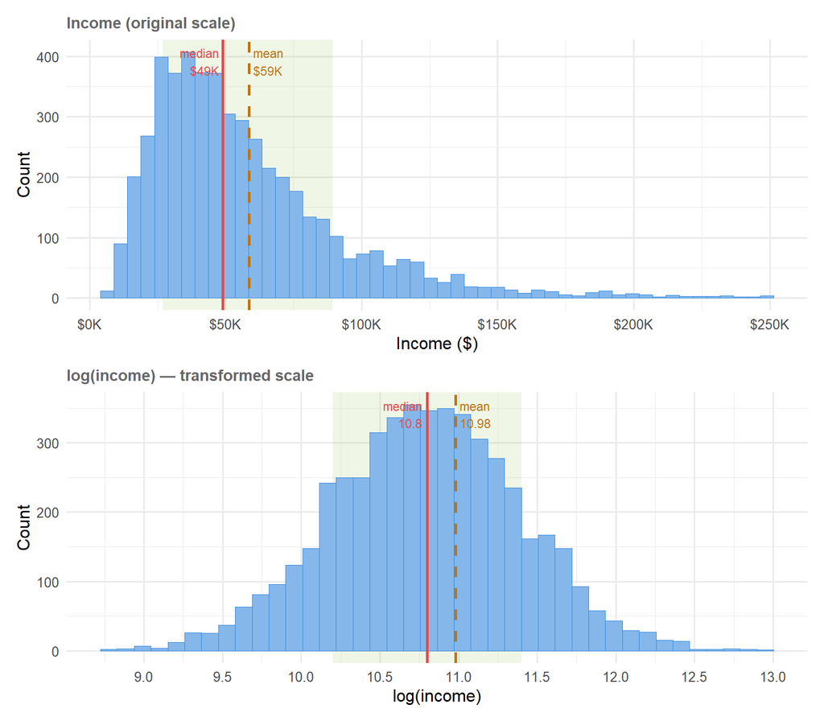

**NoteLog-Normal Parameters: What Do They Mean?**

The income variable was generated using a log-normal distribution via `rlnorm(n, meanlog = 10.8, sdlog = 0.6)`. The parameters `meanlog` and `sdlog` describe the distribution of **log(income)** — not income itself. To recover interpretable statistics on the original dollar scale:

**Median income** (the “typical” earner):
$$\text{Median} = e^{\mu} = e^{10.8} \approx \$49{,}021$$

**Mean income** (pulled up by high earners):
$$\text{Mean} = e^{\mu + \sigma^2/2} = e^{10.8 + 0.18} \approx \$58{,}689$$

**Why are they different?** Income is right-skewed — a small number of high earners pull the mean above the median. The median is preserved under exponentiation (the middle person stays the middle person), but the mean is not. The correction term $e^{\sigma^2/2}$ accounts for the skew introduced by the long right tail.

**Standard deviation** on the dollar scale is less commonly reported for log-normal data. Instead, practitioners often describe spread using the **geometric standard deviation** (GSD):
$$\text{GSD} = e^{\sigma} = e^{0.6} \approx 1.82$$

This means a typical income is within a factor of 1.82 above or below the median — roughly between $\$49{,}021 / 1.82 \approx \$26{,}935$ and $\$49{,}021 \times 1.82 \approx \$89{,}218$.

# 3 Data Splitting

## 3.1 Why We Split

The test set simulates **unseen future customers**. Any transformation parameter (mean, standard deviation, imputation value) estimated on the full dataset “leaks” information about the test set into the model — this is called **data leakage** and leads to overly optimistic performance estimates.

The golden rule: **fit everything on training data, apply to test data**.

## 3.2 Stratified Random Split

```r
mail_split <- initial_split(
  mail_data,
  prop = 0.80, # 80 % train, 20 % test
  strata = responded # preserve class balance in both sets
)

mail_train <- training(mail_split)
mail_test <- testing(mail_split)

cat("Training rows:", nrow(mail_train), "\n")
```

```
Training rows: 2400
```

```r
cat("Test rows    :", nrow(mail_test), "\n")
```

```
Test rows    : 600
```

```r
# Verify class balance is preserved
bind_rows(
  mail_train |> count(responded) |> mutate(set = "train"),
  mail_test |> count(responded) |> mutate(set = "test")
) |>
  group_by(set) |>
  mutate(pct = n / sum(n) * 100)
```

| responded | n | set | pct |
| --- | --- | --- | --- |
| yes | 127 | train | 5.291667 |
| no | 2273 | train | 94.708333 |
| yes | 34 | test | 5.666667 |
| no | 566 | test | 94.333333 |

**Tip**

**Marketing note.** Direct-mail response rates are typically 1–5 %. Stratification ensures the rare “yes” class is represented in both sets. Without it, a small test set might have almost no responders by chance.

## 3.3 ✏️ Exercise 3.1

Change `prop` to `0.70` and re-run the split. How many records move from training to test? How does the response rate change?

```r
# Your code here
```

# 4 Building a Recipe

A `recipe` is a **reusable preprocessing script** tied to a specific formula and training dataset. Steps are declared with `step_*()` functions; nothing is computed until you call `prep()`.

## 4.1 Step-by-Step Construction

```r
mail_rec <- recipe(responded ~ ., data = mail_train) |>

  # ── Step 1: Remove ID column (not a predictor) ────────────────────────────
  update_role(customer_id, new_role = "ID") |>

  # ── Step 2: Impute missing numeric values with the median ─────────────────
  step_impute_median(all_numeric_predictors()) |>

  # ── Step 3: Log-transform right-skewed numeric predictors ─────────────────
  step_log(income, avg_order_amt, recency_days, base = 10, offset = 1) |>

  # ── Step 4: Normalize (center + scale) all numeric predictors ─────────────
  step_normalize(all_numeric_predictors()) |>

  # ── Step 5: Create dummy variables from nominal predictors ─────────────────
  step_dummy(all_nominal_predictors()) |>

  # ── Step 6: Remove zero-variance predictors (safety net) ──────────────────
  step_zv(all_predictors())

mail_rec
```

### What did we just build?

```r
summary(mail_rec) # variable roles
```

| variable | type | role | source |
| --- | --- | --- | --- |
| customer_id |  | ID | original |
| age |  | predictor | original |
| income |  | predictor | original |
| recency_days |  | predictor | original |
| freq_12mo |  | predictor | original |
| avg_order_amt |  | predictor | original |
| channel |  | predictor | original |
| region |  | predictor | original |
| loyalty_tier |  | predictor | original |
| responded |  | outcome | original |

## 4.2 Deep Dive: Each Step

### 4.2.1 Imputation (`step_impute_median`)

```r
# How much is missing?
mail_train |>
  summarise(across(everything(), ~ mean(is.na(.)) * 100)) |>
  pivot_longer(
    everything(),
    names_to = "variable",
    values_to = "pct_missing"
  ) |>
  filter(pct_missing > 0) |>
  arrange(desc(pct_missing))
```

| variable | pct_missing |
| --- | --- |
| income | 7.416667 |
| avg_order_amt | 4.708333 |

**Important**

**Why median and not mean?** The median is robust to the same right-skew that makes these variables candidates for log transformation. Using the mean on a skewed distribution would impute an “average” that may not represent the typical customer.

### 4.2.2 Log Transformation (`step_log`)

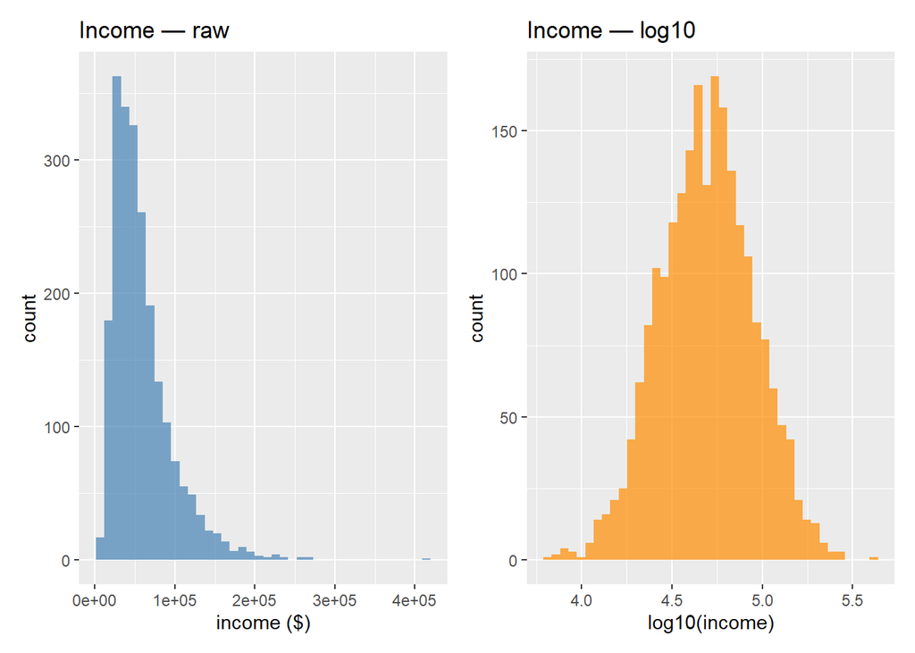

```r
# Visual: income before and after log10
p1 <- mail_train |>
  filter(!is.na(income)) |>
  ggplot(aes(income)) +
  geom_histogram(bins = 40, fill = "steelblue", alpha = 0.7) +
  labs(title = "Income — raw", x = "income ($)")

p2 <- mail_train |>
  filter(!is.na(income)) |>
  ggplot(aes(log10(income))) +
  geom_histogram(bins = 40, fill = "darkorange", alpha = 0.7) +
  labs(title = "Income — log10", x = "log10(income)")

library(patchwork)
p1 + p2
```

### 4.2.3 Normalization (`step_normalize`)

Centering and scaling puts all numeric variables on the same unit-free scale. This is *required* for distance-based models (KNN, SVM) and strongly recommended for logistic regression with regularization.

```r
# Prep just the first three steps to see the effect of normalization
rec_partial <- recipe(
  responded ~ income + freq_12mo + age,
  data = mail_train
) |>
  step_impute_median(all_numeric_predictors()) |>
  step_log(income, base = 10, offset = 1) |>
  step_normalize(all_numeric_predictors())

prep(rec_partial) |>
  bake(new_data = mail_train) |>
  summary()
```

```
     income           freq_12mo             age           responded
 Min.   :-3.51696   Min.   :-1.68323   Min.   :-3.33812   yes: 127
 1st Qu.:-0.64813   1st Qu.:-0.53996   1st Qu.:-0.69971   no :2273
 Median : 0.02051   Median : 0.03168   Median :-0.01883
 Mean   : 0.00000   Mean   : 0.00000   Mean   : 0.00000
 3rd Qu.: 0.63852   3rd Qu.: 0.60331   3rd Qu.: 0.66205
 Max.   : 3.69446   Max.   : 4.03312   Max.   : 3.04513
```

### 4.2.4 Dummy Variables (`step_dummy`)

```r
# Inspect how many dummies will be created
mail_train |>
  select(channel, region, loyalty_tier) |>
  summarise(
    channel_levels = n_distinct(channel),
    region_levels = n_distinct(region),
    loyalty_tier_levels = n_distinct(loyalty_tier)
  )
```

| channel_levels | region_levels | loyalty_tier_levels |
| --- | --- | --- |
| 3 | 4 | 4 |

`step_dummy()` creates $k - 1$ columns per factor (reference encoding) to avoid perfect multicollinearity.

# 5 Preparing and Baking

`prep()` **estimates** all statistics from the training data. `bake()` **applies** those statistics to any dataset.

```r
mail_prep <- prep(mail_rec) # learns medians, means, SDs, factor levels

# Apply to training data (already done internally, but good to inspect)
train_baked <- bake(mail_prep, new_data = NULL)
glimpse(train_baked)
```

```
Rows: 2,400
Columns: 15
$ customer_id           <chr> "C00001", "C00003", "C00004", "C00009", "C00010"…
$ age                   <dbl> 1.0024898, -0.1039406, -0.2741607, -1.2954811, -…
$ income                <dbl> 0.02051295, 0.54115533, -0.18487489, 0.01005967,…
$ recency_days          <dbl> 1.91843693, 0.23740847, -1.02014091, 0.01524220,…
$ freq_12mo             <dbl> 2.88985362, 1.74658342, -1.68322720, 0.60331321,…
$ avg_order_amt         <dbl> 1.043405055, 0.801953369, 1.257983796, -2.075965…
$ responded             <fct> no, no, no, no, no, yes, no, no, no, no, no, no,…
$ channel_direct_mail   <dbl> 0, 0, 1, 0, 0, 0, 1, 0, 0, 1, 0, 0, 0, 0, 0, 0, …
$ channel_email         <dbl> 1, 1, 0, 1, 1, 1, 0, 1, 0, 0, 1, 1, 1, 1, 1, 1, …
$ region_Northeast      <dbl> 1, 1, 0, 0, 0, 0, 1, 0, 0, 0, 0, 0, 0, 0, 0, 0, …
$ region_South          <dbl> 0, 0, 0, 0, 1, 0, 0, 1, 1, 0, 1, 1, 0, 1, 0, 0, …
$ region_West           <dbl> 0, 0, 0, 1, 0, 1, 0, 0, 0, 1, 0, 0, 0, 0, 0, 1, …
$ loyalty_tier_Gold     <dbl> 0, 0, 0, 0, 0, 1, 1, 0, 1, 0, 1, 0, 1, 0, 0, 0, …
$ loyalty_tier_Platinum <dbl> 0, 1, 0, 0, 0, 0, 0, 0, 0, 0, 0, 0, 0, 0, 0, 0, …
$ loyalty_tier_Silver   <dbl> 1, 0, 1, 1, 0, 0, 0, 1, 0, 0, 0, 0, 0, 1, 0, 0, …
```

```r
# Apply to test data — uses training statistics, NOT test statistics
test_baked <- bake(mail_prep, new_data = mail_test)
glimpse(test_baked)
```

```
Rows: 600
Columns: 15
$ customer_id           <chr> "C00002", "C00005", "C00006", "C00007", "C00008"…
$ age                   <dbl> 0.49182961, 1.17270989, 1.34292996, 0.49182961, …
$ income                <dbl> 0.28929868, 0.16376843, 0.88808272, -0.76403062,…
$ recency_days          <dbl> -1.29195910, -0.50985338, -0.13577812, 1.0475021…
$ freq_12mo             <dbl> 0.60331321, 0.03167811, -0.53995699, 0.03167811,…
$ avg_order_amt         <dbl> 0.544910311, -0.479932869, -0.496373105, 0.85877…
$ responded             <fct> no, no, no, yes, no, no, no, no, no, no, no, no,…
$ channel_direct_mail   <dbl> 0, 1, 0, 1, 0, 0, 0, 1, 1, 1, 1, 0, 0, 1, 1, 0, …
$ channel_email         <dbl> 1, 0, 1, 0, 1, 0, 1, 0, 0, 0, 0, 1, 1, 0, 0, 0, …
$ region_Northeast      <dbl> 1, 0, 0, 1, 0, 1, 0, 0, 0, 0, 0, 0, 1, 0, 1, 0, …
$ region_South          <dbl> 0, 1, 0, 0, 1, 0, 1, 0, 0, 1, 0, 0, 0, 0, 0, 0, …
$ region_West           <dbl> 0, 0, 1, 0, 0, 0, 0, 1, 1, 0, 0, 1, 0, 0, 0, 0, …
$ loyalty_tier_Gold     <dbl> 1, 0, 0, 0, 0, 0, 1, 0, 1, 1, 0, 1, 0, 0, 0, 0, …
$ loyalty_tier_Platinum <dbl> 0, 0, 0, 1, 0, 0, 0, 0, 0, 0, 1, 0, 0, 0, 0, 0, …
$ loyalty_tier_Silver   <dbl> 0, 1, 0, 0, 0, 1, 0, 0, 0, 0, 0, 0, 1, 0, 1, 0, …
```

**Warning**

**Common mistake.** Calling `prep()` on the test data separately would re-estimate the normalization parameters from test data. Always `prep()` on training, then `bake()` new data through the trained recipe.